# Plots From Large Datasets

```r
### # define vector of required packages
vec_req_pkgs <- c("tibble", "ggplot2")
### # extract vector of all installed packages
vec_inst_pkgs <- installed.packages()
### # install required packages, if necessary
for (p in vec_req_pkgs){
  if (!p %in% vec_inst_pkgs)
    install.packages(pkgs = p, repos = "https://cran.rstudio.com")
}
```

## Disclaimer

Make a few experiments with plots with large datasets

## Devices

Different devices such as `png`, `jpeg` and others require `xorg-dev` library.

## Experiments

We generate a reasonably sized dataset and try different potting options

```r
n_nr_obs <- 10^5
n_inter <- 3.24
n_slope <- 0.7
x <- runif(n_nr_obs)
y <- n_inter + n_slope * x + rnorm(n_nr_obs)
tbl_plot_data <- tibble::tibble(x = x, y = y)
```

## Plots

Normal inline plotting looks as follows

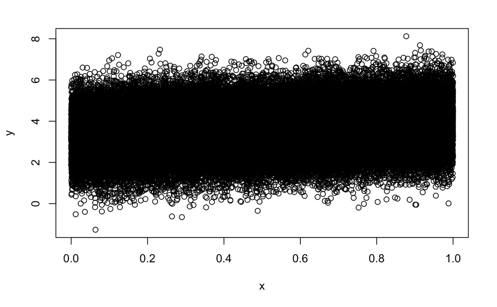

```r
plot(x,y)
```

## Plots to Files

Different devices generate different file sizes.

```r
s_file_stem <- "Rplot"
s_file_dev <- "png"
s_out_path <- paste(s_file_stem, s_file_dev, sep = ".")
png(filename = s_out_path)
plot(x,y)
dev.off()
```

The generated file has the following properties

```r
(df_png_finfo <- file.info(s_out_path))
```

|  | size | isdir | mode | mtime | ctime | atime | uid | gid | uname | grname |
| --- | --- | --- | --- | --- | --- | --- | --- | --- | --- | --- |
| Rplot.png | 65829 | FALSE | 644 | 2019-01-16 18:03:32 | 2019-01-16 18:03:32 | 2019-01-16 18:03:32 | 501 | 20 | peter | staff |

## Different Devices

### pdf

```r
s_file_stem <- "Rplot"
s_file_dev <- "pdf"
s_out_path <- paste(s_file_stem, s_file_dev, sep = ".")
pdf(file = s_out_path)
plot(x,y)
dev.off()
```

The file size here is

```r
(df_pdf_finfo <- file.info(s_out_path))
```

|  | size | isdir | mode | mtime | ctime | atime | uid | gid | uname | grname |
| --- | --- | --- | --- | --- | --- | --- | --- | --- | --- | --- |
| Rplot.pdf | 715473 | FALSE | 644 | 2019-01-16 18:03:33 | 2019-01-16 18:03:33 | 2019-01-14 07:58:22 | 501 | 20 | peter | staff |

### Postscript

```r
s_file_stem <- "Rplot"
s_file_dev <- "ps"
s_out_path <- paste(s_file_stem, s_file_dev, sep = ".")
postscript(file = s_out_path)
plot(x,y)
dev.off()
```

The file size here is

```r
(df_pdf_finfo <- file.info(s_out_path))
```

|  | size | isdir | mode | mtime | ctime | atime | uid | gid | uname | grname |
| --- | --- | --- | --- | --- | --- | --- | --- | --- | --- | --- |
| Rplot.ps | 2404211 | FALSE | 644 | 2019-01-16 18:03:34 | 2019-01-16 18:03:34 | 2019-01-14 07:58:23 | 501 | 20 | peter | staff |

## Available Options

Because the filesize of `pdf()` was smaller, we first look at options for this device. Options can be listed by

```r
pdf.options()
```

```
$width
[1] 7

$height
[1] 7

$onefile
[1] TRUE

$family
[1] "Helvetica"

$title
[1] "R Graphics Output"

$fonts
NULL

$version
[1] "1.4"

$paper
[1] "special"

$encoding
[1] "default"

$bg
[1] "transparent"

$fg
[1] "black"

$pointsize
[1] 12

$pagecentre
[1] TRUE

$colormodel
[1] "srgb"

$useDingbats
[1] TRUE

$useKerning
[1] TRUE

$fillOddEven
[1] FALSE

$compress
[1] TRUE
```

- width and height

```r
s_file_stem <- "Rplothw14"
s_file_dev <- "pdf"
s_out_path <- paste(s_file_stem, s_file_dev, sep = ".")
pdf(file = s_out_path, width = 14, height = 14)
plot(x,y)
dev.off()
```

```r
(df_pdf_finfo <- file.info(s_out_path))
```

|  | size | isdir | mode | mtime | ctime | atime | uid | gid | uname | grname |
| --- | --- | --- | --- | --- | --- | --- | --- | --- | --- | --- |
| Rplothw14.pdf | 758966 | FALSE | 644 | 2019-01-16 18:03:35 | 2019-01-16 18:03:35 | 2019-01-14 07:58:24 | 501 | 20 | peter | staff |

Changing the height and width does not make the file size smaller

```r
s_file_stem <- "Rplotps2"
s_file_dev <- "pdf"
s_out_path <- paste(s_file_stem, s_file_dev, sep = ".")
pdf(file = s_out_path, pointsize = 2)
plot(x,y)
dev.off()
```

```r
(df_pdf_finfo <- file.info(s_out_path))
```

|  | size | isdir | mode | mtime | ctime | atime | uid | gid | uname | grname |
| --- | --- | --- | --- | --- | --- | --- | --- | --- | --- | --- |
| Rplotps2.pdf | 720861 | FALSE | 644 | 2019-01-16 18:03:36 | 2019-01-16 18:03:36 | 2019-01-14 07:58:24 | 501 | 20 | peter | staff |

```r
NA
```

```r
s_file_stem <- "Rplotps24"
s_file_dev <- "pdf"
s_out_path <- paste(s_file_stem, s_file_dev, sep = ".")
pdf(file = s_out_path, pointsize = 24)
plot(x,y)
dev.off()
```

```r
(df_pdf_finfo <- file.info(s_out_path))
```

|  | size | isdir | mode | mtime | ctime | atime | uid | gid | uname | grname |
| --- | --- | --- | --- | --- | --- | --- | --- | --- | --- | --- |
| Rplotps24.pdf | 703524 | FALSE | 644 | 2019-01-16 18:03:37 | 2019-01-16 18:03:37 | 2019-01-14 07:58:25 | 501 | 20 | peter | staff |

```r
s_file_stem <- "Rplotcmg"
s_file_dev <- "pdf"
s_out_path <- paste(s_file_stem, s_file_dev, sep = ".")
pdf(file = s_out_path, colormodel = "grey")
plot(x,y)
dev.off()
```

```r
(df_pdf_finfo <- file.info(s_out_path))
```

|  | size | isdir | mode | mtime | ctime | atime | uid | gid | uname | grname |
| --- | --- | --- | --- | --- | --- | --- | --- | --- | --- | --- |
| Rplotcmg.pdf | 712614 | FALSE | 644 | 2019-01-16 18:03:37 | 2019-01-16 18:03:37 | 2019-01-14 07:58:26 | 501 | 20 | peter | staff |

## More tools

### compactPDF

The function `tools::compactPDF()` did not work

### grid.raster

From https://journal.r-project.org/archive/2011-1/RJournal_2011-1_Murrell.pdf, we get the following example code-junk

```r
library(grid)
z <- matrix(runif(500*500), ncol=500)
pdf("image.pdf")
image(z, col=grey(0:99/100))
dev.off()
```

```r
pdf("gridraster.pdf")
```

```r
grid.raster(z, interp=FALSE)
dev.off()
```

```r
file.info("image.pdf", "gridraster.pdf")["size"]
```

|  | size |
| --- | --- |
| image.pdf | 1248530 |
| gridraster.pdf | 367809 |

To use the `grid.raster()` function, we have to convert the scatter-plot into a raster matrix. One possible way of doing this is via a 2D density estimate. Sources for this are available at https://www.r-bloggers.com/5-ways-to-do-2d-histograms-in-r/ or https://www.datacamp.com/community/tutorials/bivariate-heatmaps. For other useful plotting stuff, also consider http://dwoll.de/rexrepos/posts/diagDistributions.html.

For our example, we use the default call from https://www.r-bloggers.com/5-ways-to-do-2d-histograms-in-r/ which uses the function `MASS::kde2d()`.

```r
### # start with color housekeeping
# Color housekeeping
library(RColorBrewer)
rf <- colorRampPalette(rev(brewer.pal(11,'Spectral')))
r <- rf(32)

library(MASS)
# use default call
k <- kde2d(tbl_plot_data$x, tbl_plot_data$y, n = 200)
### # default image
s_image_plot <- "image_plot.pdf"
pdf(s_image_plot)
image(k, col = r)
dev.off()
```

```r
file.info(s_image_plot)["size"]
```

|  | size |
| --- | --- |
| image_plot.pdf | 137198 |

Now we use `grid.raster()` on `k$z` instead of `image()`

```r
### # default image
s_raster_plot <- "gridraster_plot.pdf"
pdf(s_raster_plot)
### # the following does not work, have to find a way how to convert k to raster
grid.raster(t(k$z), interp=FALSE)
dev.off()
```

```r
file.info(s_raster_plot)["size"]
```

|  | size |
| --- | --- |
| gridraster_plot.pdf | 12347 |

The above command does produce a raster image although we have to consider that it is very different from the ones produced with image. It looks rotated and very fuzzy and hence none of the outliers can be detected.

### smoothscatter

Avoiding effects of overplotting with a smoothed version of the scatterplot. See https://www.stat.ubc.ca/~jenny/STAT545A/block91_latticeGraphics.html for more details.

```r
s_out_path <- "RsmoothScatter.pdf"
pdf(s_out_path)
smoothScatter(y ~ x, colramp = colorRampPalette(c("white", blues9)), xlim = c(0,1), ylim = c(0, 8))
dev.off()
file.info(s_out_path)["size"]
```

### ggsave

The plot is drawn with `ggplot2` and `ggsave()` is used to save the plot to a file

```r
s_out_path <- "Rggplot2.pdf"
library(ggplot2)
ggplot(tbl_plot_data, aes(x,y)) + geom_point()
ggsave(s_out_path, width = 4, height = 4, dpi = "screen")
(df_ggplot_pdf_finfo <- file.info(s_out_path))
```

Using a different file extension

```r
s_out_path <- "Rggplot2.png"
library(ggplot2)
ggplot(tbl_plot_data, aes(x,y)) + geom_point()
ggsave(s_out_path, width = 4, height = 4, dpi = "screen")
(df_ggplot_png_finfo <- file.info(s_out_path))
```

More options of `ggsave()`

```r
?ggsave
```

Based on the body of function `ggsave()`, the plot devices are generated by `ggplot2:::plot_dev()` and inside that function `grDevices::png()` is called to produce a `png`-plot. From the help of `grDevices::png()` it is clear that this function also depends on `X11` functionality.

### CairoPng

From Chang2013 (R Graphics Cookbook) p. 345 …

```r
s_out_path <- "RplotCairo.png"
Cairo::CairoPNG(filename = s_out_path)
plot(x, y)
dev.off()
(df_cairo_png_info <- file.info(s_out_path))
```

Compilation of `Cairo` on Ubuntu 16.04 lts fails with the following error

```
checking for pkg-config... no
configure: CAIRO_LIBS is unset, attempting to guess it.
configure: CAIRO_CFLAGS=
checking if R was compiled with the RConn patch... no
checking cairo.h usability... no
checking cairo.h presence... no
checking for cairo.h... no
configure: error: Cannot find cairo.h! Please install cairo (http://www.cairographics.org/) and/or set CAIRO_CFLAGS/LIBS correspondingly.
ERROR: configuration failed for package 'Cairo'
* removing '/home/zws/lib/R/library/Cairo'

Die heruntergeladenen Quellpakete sind in
        '/tmp/Rtmpr8wC2N/downloaded_packages'
Warnmeldung:
In install.packages("Cairo", repos = "https://cran.rstudio.com") :
  Installation des Pakets 'Cairo' hatte Exit-Status ungleich 0
```

As can be seen from https://stackoverflow.com/questions/51940792/r-cairo-package-installation-failed-in-ubuntu-18-04, X11 and other libraries are used to compile `Cairo`.